# Practical Machine Learning: Course Assignment

Christoph Schauer

13 May 2018

## Introduction

This notebook contains the code of the course project for the course [Practical Machine Learning](https://www.coursera.org/learn/practical-machine-learning) of the [Data Science Specialization](https://www.coursera.org/specializations/jhu-data-science) by John Hopkins University on Coursera, lightly edited for clarity. The goal of this project is to predict the way in which participants of a study performed certain exercises using motion data from wearables.

From the description of the assignment:

*Using devices such as Jawbone Up, Nike FuelBand, and Fitbit it is now possible to collect a large amount of data about personal activity relatively inexpensively. These type of devices are part of the quantified self movement - a group of enthusiasts who take measurements about themselves regularly to improve their health, to find patterns in their behavior, or because they are tech geeks. One thing that people regularly do is quantify how much of a particular activity they do, but they rarely quantify how well they do it. In this project, your goal will be to use data from accelerometers on the belt, forearm, arm, and dumbell of 6 participants. They were asked to perform barbell lifts correctly and incorrectly in 5 different ways. More information is available from the website here:*

*The goal of your project is to predict the manner in which they did the exercise. This is the “classe” variable in the training set. You may use any of the other variables to predict with. You should create a report describing how you built your model, how you used cross validation, what you think the expected out of sample error is, and why you made the choices you did. You will also use your prediction model to predict 20 different test cases.*

The data is from the following study:

Velloso, E.; Bulling, A.; Gellersen, H.; Ugulino, W.; Fuks, H. *“Qualitative Activity Recognition of Weight Lifting Exercises. Proceedings of 4th International Conference in Cooperation with SIGCHI (Augmented Human ’13)”*. Stuttgart, Germany: ACM SIGCHI, 2013.

In this study, data was collected from accelerometers on the belt, forearm, arm, and dumbell of 6 participants. The participants were asked to perform barbell lifts correctly and incorrectly in 5 different ways. More information is available here: http://groupware.les.inf.puc-rio.br/har.

A short description of the datasets from the authors’ website:

*Six young health participants were asked to perform one set of 10 repetitions of the Unilateral Dumbbell Biceps Curl in five different fashions: exactly according to the specification (Class A), throwing the elbows to the front (Class B), lifting the dumbbell only halfway (Class C), lowering the dumbbell only halfway (Class D) and throwing the hips to the front (Class E).*

*Class A corresponds to the specified execution of the exercise, while the other 4 classes correspond to common mistakes. Participants were supervised by an experienced weight lifter to make sure the execution complied to the manner they were supposed to simulate. The exercises were performed by six male participants aged between 20-28 years, with little weight lifting experience. We made sure that all participants could easily simulate the mistakes in a safe and controlled manner by using a relatively light dumbbell (1.25kg).*

The training data for this project is available here: https://d396qusza40orc.cloudfront.net/predmachlearn/pml-training.csv

The evaluation data (used for evaluating prediction accuracy in quiz in the assignment) is available here: https://d396qusza40orc.cloudfront.net/predmachlearn/pml-testing.csv

## Approach

For this kind of data, nonparametric models are likely to yield the good results. I estimated two nonparametric ensemble learning models: Random forests and boosted decision trees. As both approaches are intrinsically blended models that use a large number of bootstrapped subsamples for their estimations, I only split the data into one training and one test sample without additional resampling such as k-fold cross-validation.

The final random forest model proves highly accurate and performs better than the boosted model. The model is able to predict all 20 classes from the evaluation set correctly.

### Load required packages

```r
library(caret)
library(randomForest)
library(gbm)
library(ggplot2)
library(ggpubr)
```

### Load and clean up data

```r
pml_training = read.csv("pml-training.csv", stringsAsFactors = FALSE)
pml_testing = read.csv("pml-testing.csv", stringsAsFactors = FALSE)
classe = as.factor(pml_training$classe)
numeric_vars = data.frame(lapply(pml_training[, 8:159], function(x) as.numeric(as.character(x))))
data_full = data.frame(classe, numeric_vars)
```

Dimensions of the data set:

```r
dim(data_full)
```

```
## [1] 19622   153
```

The data, data_full, excludes some variables from the raw data which not needed for analysis (ID, participant names, date and time variables, and window variables). All motion data is converted from various data types to numeric. The dataset contains 19622 observations and 153 variables.

### Partition data into a training and test set

```r
set.seed(123)
in_train = createDataPartition(y = data_full$classe, p = 0.6, list = FALSE)
data_train  = data_full[in_train, ]
data_test  = data_full[-in_train, ]
```

Dimensions of the data:

```r
dim(data_train)
```

```
## [1] 11776   153
```

```r
dim(data_test)
```

```
## [1] 7846  153
```

```r
table(data_train$classe)
```

```
##
##    A    B    C    D    E
## 3348 2279 2054 1930 2165
```

60% of all observations are randomly put into the training set, 40% into the test set. Sampling happens without replacement. The training set contains 11776 observations, the test set 7846. The table shows that there is a similar amount of observations for each way in which participants performed the exercise, i.e. the factors of the dependent variable “classe”.

### Drop variables with many missing values and near zero variance

Many of the variables of this data set have very high numbers of missing observations and are therefore not very useful for prediction. All variables with more than 95% of values missing are therefore excluded.

```r
NA95 = sapply(data_train, function(x) mean(is.na(x))) > 0.95
data_train = data_train[, NA95 == FALSE]
data_test = data_test[, NA95 == FALSE]
dim(data_train)
```

```
## [1] 11776    53
```

Of the 152 explanatory variables, 100 are dropped, leaving 52 in the data set.

Variables with near zero variance are excluded as well. Variables that vary barely or not at all are not useful for prediction.

```r
nearZeroVar(data_train)
```

```
## integer(0)
```

As it happens, after excluding all variables with more than 95% of values missing, no variable with near zero variance remains in the data.

## Visualizations

Violin plots with the most influential variables (see random forest section) show that there seem to be some differences in distribution between the classes of activities, but they’re not super clear cut.

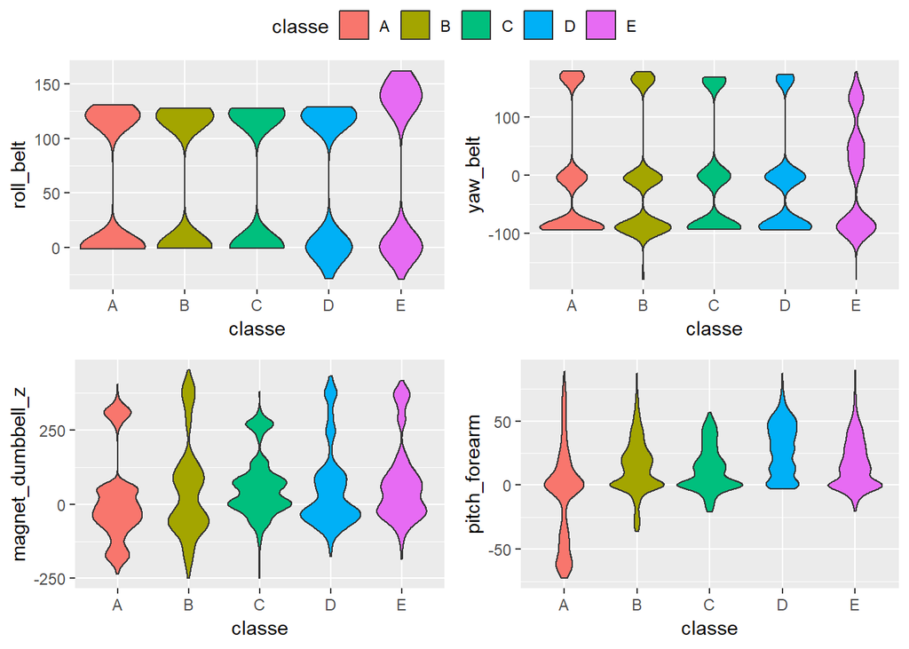

```r
ggarrange(
     ggplot(data_train) + geom_violin(aes(classe, roll_belt, fill = classe)),
     ggplot(data_train) + geom_violin(aes(classe, yaw_belt, fill = classe)),
     ggplot(data_train) + geom_violin(aes(classe, magnet_dumbbell_z, fill = classe)),
     ggplot(data_train) + geom_violin(aes(classe, pitch_forearm, fill = classe)),
     ncol = 2, nrow = 2, common.legend = TRUE
)
```

Scatterplots of some of the influential variables illustrate the potential for separation better:

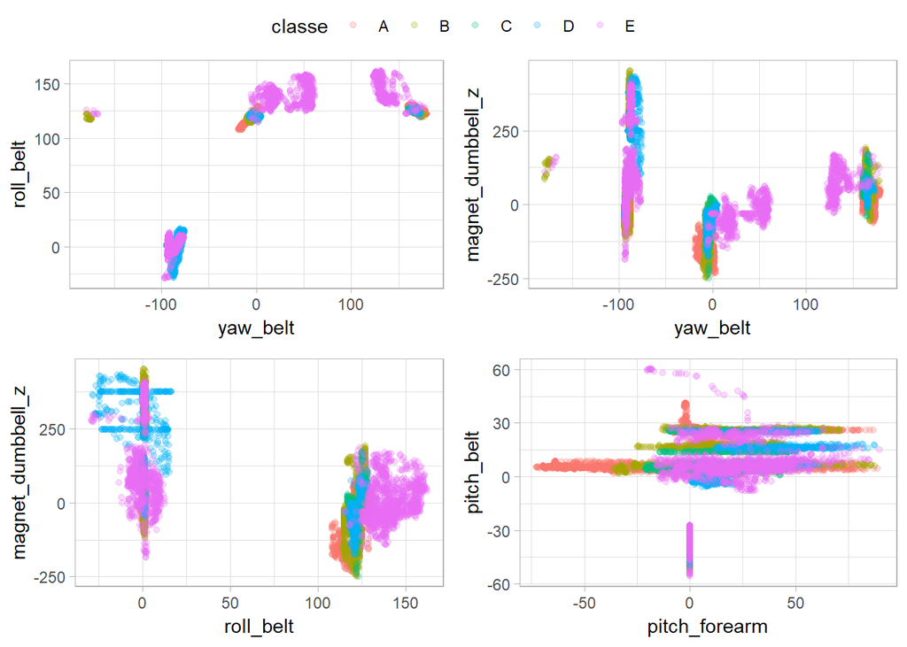

```r
ggarrange(
     ggplot(data_train) + geom_point(aes(x = yaw_belt, y = roll_belt, color = classe), alpha = 0.25) +
          theme_light(),
     ggplot(data_train) + geom_point(aes(x = yaw_belt, y = magnet_dumbbell_z, color = classe), alpha = 0.25) +
          theme_light(),
     ggplot(data_train) + geom_point(aes(x = roll_belt, y = magnet_dumbbell_z, color = classe), alpha = 0.25) +
          theme_light(),
     ggplot(data_train) + geom_point(aes(x = pitch_forearm, y = pitch_belt, color = classe), alpha = 0.25) +
          theme_light(),
     ncol = 2, nrow = 2, common.legend = TRUE
)
```

### Estimate random forest models on training sample

```r
set.seed(123)
forest3 = randomForest(classe ~ ., data = data_train, ntree = 500, mtry = 3, importance = TRUE)
forest5 = randomForest(classe ~ ., data = data_train, ntree = 500, mtry = 5, importance = TRUE)
forest7 = randomForest(classe ~ ., data = data_train, ntree = 500, mtry = 7, importance = TRUE)
forest9 = randomForest(classe ~ ., data = data_train, ntree = 500, mtry = 9, importance = TRUE)

forest3
```

```
##
## Call:
##  randomForest(formula = classe ~ ., data = data_train, ntree = 500,      mtry = 3, importance = TRUE)
##                Type of random forest: classification
##                      Number of trees: 500
## No. of variables tried at each split: 3
##
##         OOB estimate of  error rate: 0.81%
## Confusion matrix:
##      A    B    C    D    E class.error
## A 3344    2    1    0    1 0.001194743
## B   15 2262    2    0    0 0.007459412
## C    1   26 2022    5    0 0.015579357
## D    1    0   33 1894    2 0.018652850
## E    0    0    1    5 2159 0.002771363
```

```r
forest5
```

```
##
## Call:
##  randomForest(formula = classe ~ ., data = data_train, ntree = 500,      mtry = 5, importance = TRUE)
##                Type of random forest: classification
##                      Number of trees: 500
## No. of variables tried at each split: 5
##
##         OOB estimate of  error rate: 0.65%
## Confusion matrix:
##      A    B    C    D    E  class.error
## A 3345    2    0    0    1 0.0008960573
## B   10 2265    4    0    0 0.0061430452
## C    0   17 2033    4    0 0.0102239533
## D    2    0   29 1897    2 0.0170984456
## E    0    0    2    4 2159 0.0027713626
```

```r
forest7
```

```
##
## Call:
##  randomForest(formula = classe ~ ., data = data_train, ntree = 500,      mtry = 7, importance = TRUE)
##                Type of random forest: classification
##                      Number of trees: 500
## No. of variables tried at each split: 7
##
##         OOB estimate of  error rate: 0.68%
## Confusion matrix:
##      A    B    C    D    E class.error
## A 3343    3    0    1    1 0.001493429
## B   12 2264    3    0    0 0.006581834
## C    0   18 2031    5    0 0.011197663
## D    1    0   25 1902    2 0.014507772
## E    0    0    2    7 2156 0.004157044
```

```r
forest9
```

```
##
## Call:
##  randomForest(formula = classe ~ ., data = data_train, ntree = 500,      mtry = 9, importance = TRUE)
##                Type of random forest: classification
##                      Number of trees: 500
## No. of variables tried at each split: 9
##
##         OOB estimate of  error rate: 0.66%
## Confusion matrix:
##      A    B    C    D    E class.error
## A 3344    2    0    0    2 0.001194743
## B   11 2264    4    0    0 0.006581834
## C    1   17 2031    5    0 0.011197663
## D    1    0   25 1902    2 0.014507772
## E    0    0    2    6 2157 0.003695150
```

```r
classe.rf3 = predict(forest3, newdata = data_test)
classe.rf5 = predict(forest5, newdata = data_test)
classe.rf7 = predict(forest7, newdata = data_test)
classe.rf9 = predict(forest9, newdata = data_test)

table(classe.rf3, data_test$classe)
```

```
##
## classe.rf3    A    B    C    D    E
##          A 2231    9    0    0    0
##          B    1 1506   11    0    0
##          C    0    3 1355   21    2
##          D    0    0    2 1265    4
##          E    0    0    0    0 1436
```

```r
table(classe.rf5, data_test$classe)
```

```
##
## classe.rf5    A    B    C    D    E
##          A 2231    9    0    0    0
##          B    1 1506    9    0    0
##          C    0    3 1357   12    2
##          D    0    0    2 1274    5
##          E    0    0    0    0 1435
```

```r
table(classe.rf7, data_test$classe)
```

```
##
## classe.rf7    A    B    C    D    E
##          A 2230    8    0    0    0
##          B    2 1507   10    0    0
##          C    0    3 1353   13    3
##          D    0    0    5 1273    4
##          E    0    0    0    0 1435
```

```r
table(classe.rf9, data_test$classe)
```

```
##
## classe.rf9    A    B    C    D    E
##          A 2230    9    0    0    0
##          B    2 1506   12    0    0
##          C    0    3 1350   12    3
##          D    0    0    6 1274    4
##          E    0    0    0    0 1435
```

```r
table(classe.rf3 == data_test$classe) # rf5
```

```
##
## FALSE  TRUE
##    53  7793
```

```r
table(classe.rf5 == data_test$classe) # rf5
```

```
##
## FALSE  TRUE
##    43  7803
```

```r
table(classe.rf7 == data_test$classe) # rf7
```

```
##
## FALSE  TRUE
##    48  7798
```

```r
table(classe.rf9 == data_test$classe) # rf9
```

```
##
## FALSE  TRUE
##    51  7795
```

The following variables are the most influential in the random forest model:

```r
importance = rowMeans(forest7$importance)
importance = sort(importance, decreasing = TRUE)
head(importance, 10)
```

```
##         roll_belt          yaw_belt magnet_dumbbell_z     pitch_forearm
##         105.64658          76.62929          66.57598          64.46546
##        pitch_belt magnet_dumbbell_y      roll_forearm magnet_dumbbell_x
##          59.03250          57.15802          51.73923          40.53748
##      accel_belt_z     roll_dumbbell
##          37.26862          36.51529
```

## Estimate boosted classification tree model

This model successively grows 500 trees with 7 leaves each, and is using all the default options otherwise. The package used for estimation is gbm.

```r
boost7 = gbm(classe ~ ., data = data_train, n.trees = 500, distribution = "multinomial",
              interaction.depth = 7)
boost7
```

```
## gbm(formula = classe ~ ., distribution = "multinomial", data = data_train,
##     n.trees = 500, interaction.depth = 7)
## A gradient boosted model with multinomial loss function.
## 500 iterations were performed.
## There were 52 predictors of which 52 had non-zero influence.
```

```r
classe.boost7 = predict(boost7, newdata = data_test, n.trees = 500, type = "response")
classe.boost7 = apply(classe.boost7, 1, which.max)
table(classe.boost7, data_test$classe)
```

```
##
## classe.boost7    A    B    C    D    E
##             1 2230    5    0    0    0
##             2    1 1509   11    0    0
##             3    1    4 1346    7    2
##             4    0    0   11 1277    5
##             5    0    0    0    2 1435
```

The results stay worse than those of the random forest model even if the number of trees and leaves grown are varied. Results are not shown because it takes a bit to compute.

## Generate predictions for quiz data

```r
data_quiz = data.frame(lapply(pml_testing[, 8:159], function(x) as.numeric(as.character(x))))
data_quiz = data_quiz[, NA95[-1] == FALSE]
classe.rf7.quiz = predict(forest7, newdata = data_quiz)
classe.rf7.quiz
```

```
##  1  2  3  4  5  6  7  8  9 10 11 12 13 14 15 16 17 18 19 20
##  B  A  B  A  A  E  D  B  A  A  B  C  B  A  E  E  A  B  B  B
## Levels: A B C D E
```

These predictions are used to evualuate the prediction accuracy of the model in quiz. The estimated random forest model predicts all cases correctly.

## Addendum

### Estimating a random forest model with caret

At the time of doing the assignment, I wasn’t very familiar with caret, so I didn’t use it for estimating the random forest model. Caret optimizes a couple of parameters automatically. The following code estimates a random forest in caret, using only 100 trees to speed up computations.

```r
set.seed(123)
caretforest = train(classe ~ ., data = data_train, method = "rf", ntree = 100)
caretforest
```

```
## Random Forest
##
## 11776 samples
##    52 predictor
##     5 classes: 'A', 'B', 'C', 'D', 'E'
##
## No pre-processing
## Resampling: Bootstrapped (25 reps)
## Summary of sample sizes: 11776, 11776, 11776, 11776, 11776, 11776, ...
## Resampling results across tuning parameters:
##
##   mtry  Accuracy   Kappa
##    2    0.9853365  0.9814477
##   27    0.9860756  0.9823850
##   52    0.9762307  0.9699284
##
## Accuracy was used to select the optimal model using the largest value.
## The final value used for the model was mtry = 27.
```

```r
classe.caretforest = predict(caretforest, newdata = data_test)
table(classe.caretforest, data_test$classe)
```

```
##
## classe.caretforest    A    B    C    D    E
##                  A 2228   12    0    0    0
##                  B    4 1501   11    0    1
##                  C    0    5 1344   19    5
##                  D    0    0   13 1267    6
##                  E    0    0    0    0 1430
```

```r
table(classe.caretforest == data_test$classe)
```

```
##
## FALSE  TRUE
##    76  7770
```